# Catchment land use and estuary and coastal fish communities

Ecosystems are connected by flows of matter and organisms: what one ecosystem exports shapes the recipient one. This is idea of Loreau et al. (2003), Gounand et al. (2018)]. Rivers deliver to estuaries and coastal waters the nutrients, sediment and freshwater released by their catchment. Here, we ask how the land use and climate of the catchment shape the fish communities of estuaries and coastal bays, in the four districts of interest.

Here are our hypotheses of driver impacts on estuarine and coastal ecosystems.

**Hypotheses.** Fish are grouped by their use of estuaries (guilds, see below).

[output not shown]

Steps: (1) data and guilds, (2) the catchment of the estuary of each operation, (3) models of the communities (to come).

## Setup

```r
library(renv)
renv::load()
```

```
- The project is out-of-sync -- use `renv::status()` for details.
```

```r
library(targets)
library(here)
tar_config_set(
  store = here::here("_targets")
)
library(ggplot2)
library(dplyr)
devtools::load_all()
nice_theme()
```

```r
guild_label <- c(
  MS = "Marine straggler", MM = "Marine migrant (juveniles)", ER = "Estuarine resident",
  CA = "Diadromous", FW = "Freshwater"
)
colour_guild <- c(
  `Marine straggler` = "#56B4E9", `Marine migrant (juveniles)` = "#0072B2",
  `Estuarine resident` = "#009E73", Diadromous = "#E69F00", Freshwater = "#CC79A7"
)
colour_effect <- c(Positive = "#2166AC", `Not credible` = "grey70", Negative = "#B2182B")
survey_label <- c(pomet = "POMET (estuaries)", nurse = "Nursery survey (coastal bays)")
colour_survey <- c(`POMET (estuaries)` = "#D55E00", `Nursery survey (coastal bays)` = "#0072B2")
```

## Data

Two trawling survey surveys: POMET and nursery survey (NURSE).

We keep the operations of the four districts, at sea and inland (upper estuaries), with their distance to the river mouth (D8; target `sea_operation`). Each operation is then linked to a river mouth (see Catchment of each estuary).

Salinity is measured at most POMET operations; for the nursery survey and the other POMET operations, it is taken from the yearly modeled environment of the Bay of Biscay coast.

```r
operation <- tar_read(sea_operation)
catch <- tar_read(sea_catch)
operation |>
  summarise(
    Operations = n(),
    Years = paste(min(year), max(year), sep = "-"),
    Months = paste(sort(unique(month)), collapse = ", "),
    `Salinity measured` = scales::percent(mean(salinity_source == "measured", na.rm = TRUE), 1),
    `Salinity from the grid` = scales::percent(mean(salinity_source == "grid", na.rm = TRUE), 1),
    `No salinity` = sum(is.na(salinity)),
    .by = c(survey, gear)
  ) |>
  mutate(survey = survey_label[survey]) |>
  rename(Survey = survey, Gear = gear) |>
  knitr::kable()
```

| Survey | Gear | Operations | Years | Months | Salinity measured | Salinity from the grid | No salinity |
| --- | --- | --- | --- | --- | --- | --- | --- |
| POMET (estuaries) | beam trawl 1.46m | 4481 | 2005-2019 | 4, 5, 6, 7, 8, 9, 10, 11 | 99% | 1% | 118 |
| POMET (estuaries) | beam trawl 3m | 2283 | 2005-2018 | 4, 5, 6, 7, 8, 9, 10, 11 | 98% | 2% | 61 |
| Nursery survey (coastal bays) | beam trawl nursery | 1538 | 2005-2022 | 8, 9, 10 | 0% | 100% | 0 |

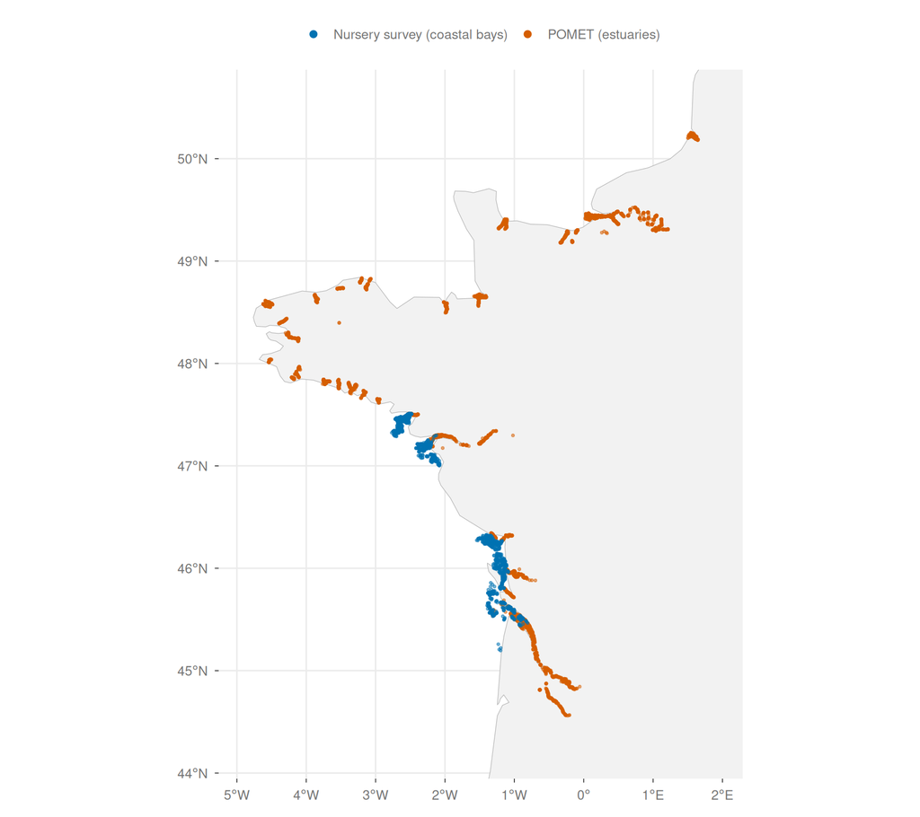

Operations of the two surveys in the four districts.

```r
france <- rnaturalearth::ne_countries(scale = "medium", country = "France", returnclass = "sf")
ggplot() +
  geom_sf(data = france, fill = "grey95", color = "grey70", linewidth = 0.2) +
  geom_point(
    aes(longitude, latitude, color = survey_label[survey]),
    data = operation, size = 0.6, alpha = 0.5
  ) +
  coord_sf(xlim = range(operation$longitude) + c(-0.3, 0.3), ylim = range(operation$latitude) + c(-0.3, 0.3)) +
  scale_color_manual(values = colour_survey) +
  labs(x = NULL, y = NULL, color = NULL) +
  guides(color = guide_legend(override.aes = list(size = 2, alpha = 1))) +
  theme(legend.position = "top", axis.line = element_blank())
```

### Species and guilds

Each species is classed by its use of estuaries, from the guilds of the POMET reference (target `estuary_guild`), matched on the names validated against FishBase (the reference uses older names, e.g. *Liza ramada* for *Chelon ramada*), completed by hand for the species missing from it and corrected by hand for a few (target `species_guild`, notes in the table below).

The five guilds are the estuarine-use functional groups of Elliott and Quintino (2007).

[output not shown]

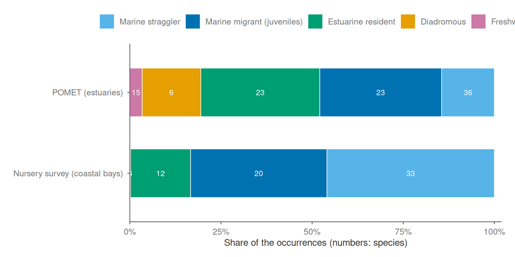

Number of species of each guild and share of the occurrences (species x operation), per survey.

```r
catch |>
  inner_join(select(operation, operation_id, survey), by = "operation_id") |>
  mutate(guild = coalesce(guild_label[guild], "Unclassified")) |>
  summarise(species = n_distinct(species), occurrences = n(), .by = c(survey, guild)) |>
  mutate(share = occurrences / sum(occurrences), .by = survey) |>
  mutate(
    survey = survey_label[survey],
    guild = factor(guild, c(names(colour_guild), "Unclassified"))
  ) |>
  ggplot(aes(share, survey, fill = guild)) +
  geom_col(width = 0.6, color = "white", linewidth = 0.3) +
  geom_text(
    aes(label = species), position = position_stack(vjust = 0.5), size = 3, color = "white"
  ) +
  scale_fill_manual(values = c(colour_guild, Unclassified = "grey70")) +
  scale_x_continuous(labels = scales::percent, expand = expansion(mult = c(0, 0.02))) +
  labs(x = "Share of the occurrences (numbers: species)", y = NULL, fill = NULL) +
  theme(legend.position = "top", panel.grid.major.y = element_blank())
```

```r
species_guild <- tar_read(species_guild)
catch |>
  inner_join(select(operation, operation_id, survey), by = "operation_id") |>
  count(species, survey) |>
  tidyr::pivot_wider(names_from = survey, values_from = n, values_fill = 0) |>
  inner_join(species_guild, by = "species") |>
  mutate(guild = factor(guild_label[guild], guild_label)) |>
  arrange(guild, desc(pomet + nurse)) |>
  transmute(
    Species = paste0("*", species, "*"), Guild = guild,
    `POMET operations` = pomet, `Nursery survey operations` = nurse,
    `Guild source` = source, Note = coalesce(note, "")
  ) |>
  knitr::kable()
```

| Species | Guild | POMET operations | Nursery survey operations | Guild source | Note |
| --- | --- | --- | --- | --- | --- |
| *Callionymus lyra* | Marine straggler | 869 | 1129 | POMET reference |  |
| *Buglossidium luteum* | Marine straggler | 311 | 680 | POMET reference |  |
| *Arnoglossus laterna* | Marine straggler | 184 | 685 | POMET reference |  |
| *Aphia minuta* | Marine straggler | 502 | 161 | POMET reference |  |
| *Echiichthys vipera* | Marine straggler | 551 | 22 | POMET reference |  |
| *Mullus surmuletus* | Marine straggler | 113 | 446 | POMET reference |  |
| *Atherina presbyter* | Marine straggler | 256 | 209 | POMET reference |  |
| *Dicologlossa cuneata* | Marine straggler | 15 | 302 | POMET reference |  |
| *Ammodytes tobianus* | Marine straggler | 273 | 2 | POMET reference |  |
| *Merluccius merluccius* | Marine straggler | 18 | 249 | POMET reference |  |
| *Conger conger* | Marine straggler | 39 | 175 | POMET reference |  |
| *Spondyliosoma cantharus* | Marine straggler | 132 | 81 | POMET reference |  |
| *Pegusa lascaris* | Marine straggler | 136 | 23 | POMET reference |  |
| *Raja clavata* | Marine straggler | 127 | 25 | POMET reference |  |
| *Labrus bergylta* | Marine straggler | 124 | 6 | POMET reference |  |
| *Eutrigla gurnardus* | Marine straggler | 20 | 106 | POMET reference |  |
| *Trisopterus minutus* | Marine straggler | 75 | 48 | POMET reference |  |
| *Ctenolabrus rupestris* | Marine straggler | 113 | 3 | POMET reference |  |
| *Arnoglossus thori* | Marine straggler | 98 | 4 | POMET reference |  |
| *Zeus faber* | Marine straggler | 49 | 37 | POMET reference |  |
| *Scyliorhinus canicula* | Marine straggler | 7 | 68 | POMET reference |  |
| *Hyperoplus lanceolatus* | Marine straggler | 57 | 15 | POMET reference |  |
| *Agonus cataphractus* | Marine straggler | 63 | 0 | POMET reference |  |
| *Umbrina canariensis* | Marine straggler | 23 | 39 | POMET reference |  |
| *Raja undulata* | Marine straggler | 38 | 19 | POMET reference |  |
| *Torpedo marmorata* | Marine straggler | 9 | 45 | POMET reference |  |
| *Taurulus bubalis* | Marine straggler | 41 | 0 | POMET reference |  |
| *Microchirus variegatus* | Marine straggler | 14 | 25 | POMET reference |  |
| *Sparus aurata* | Marine straggler | 28 | 4 | POMET reference |  |
| *Chelidonichthys cuculus* | Marine straggler | 0 | 17 | added by hand | Marine species, occasional in estuaries |

[output cut: 78 more lines]

## Catchment of each estuary

Each operation is linked to the main river flowing into its estuary or bay, and related to the land use of that river’s catchment. Small streams entering the same estuary (e.g. the marsh channels along the Gironde) are merged with its main river: the water of the estuary comes mostly from it.

- **Main rivers:** the AMOBIO river mouths (as in D8) draining 1,000 km² or more; mouths closer than 3 km are pooled (e.g. the Orne and the Dan at Caen).
- **Catchments:** computed on the HydroSHEDS flow directions (~400 m, as in D15). Each grid outlet takes the main river its stream reaches along the AMOBIO network: e.g. the Garonne and the Dordogne, which end at the head of the Gironde on the grid. Land cover and weather are read from the cached catchment rasters of D15.
- **Operations:** inland (upper estuaries), the main river reached along the network; at sea, the nearest main river mouth along the sea (D8), if within 15 km. The other operations are dropped. By hand: the operations of the Gironde estuary belong to the Gironde (the AMOBIO Gironde ends at its head, 20 to 70 km from them).

Targets: `main_mouth`, `network_mouth`, `mouth_outlet`, `sea_operation_mouth`, `mouth_catchment`.

```r
mouth <- tar_read(sea_mouth_area)
basin <- tar_read(mouth_basin)
operation_mouth <- operation |>
  select(operation_id, survey, district, longitude, latitude) |>
  left_join(tar_read(sea_operation_mouth), by = "operation_id")
mouth_used <- mouth |>
  filter(mouth_id %in% operation_mouth$mouth_id) |>
  arrange(district, desc(latitude))
palette_mouth <- c("#E69F00", "#56B4E9", "#009E73", "#D55E00", "#0072B2", "#CC79A7", "#8C6D31")
colour_mouth <- setNames(rep_len(palette_mouth, nrow(mouth_used)), mouth_used$mouth_id)
```

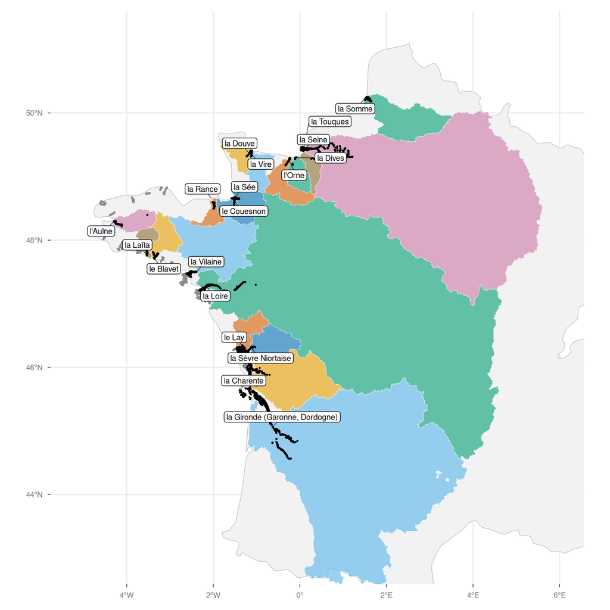

Catchments of the main rivers with operations (one colour per river), and the operations kept (black) or dropped (grey, more than 15 km from a main river mouth at sea).

```r
ggplot() +
  geom_sf(data = france, fill = "grey95", color = "grey70", linewidth = 0.2) +
  geom_sf(aes(fill = factor(mouth_id)), data = filter(basin, mouth_id %in% mouth_used$mouth_id), color = "white", linewidth = 0.1, alpha = 0.6) +
  geom_point(aes(longitude, latitude), data = filter(operation_mouth, is.na(mouth_id)), size = 0.2, color = "grey55") +
  geom_point(aes(longitude, latitude), data = filter(operation_mouth, !is.na(mouth_id)), size = 0.2) +
  ggrepel::geom_label_repel(
    aes(longitude, latitude, label = river), data = mouth_used,
    size = 2.6, label.size = 0.1, label.padding = 0.15, min.segment.length = 0, segment.size = 0.2, seed = 1
  ) +
  coord_sf(xlim = c(-5.2, 6), ylim = c(43, 51.2)) +
  scale_fill_manual(values = colour_mouth, guide = "none") +
  labs(x = NULL, y = NULL) +
  theme(axis.line = element_blank(), axis.text = element_text(size = 7))
```

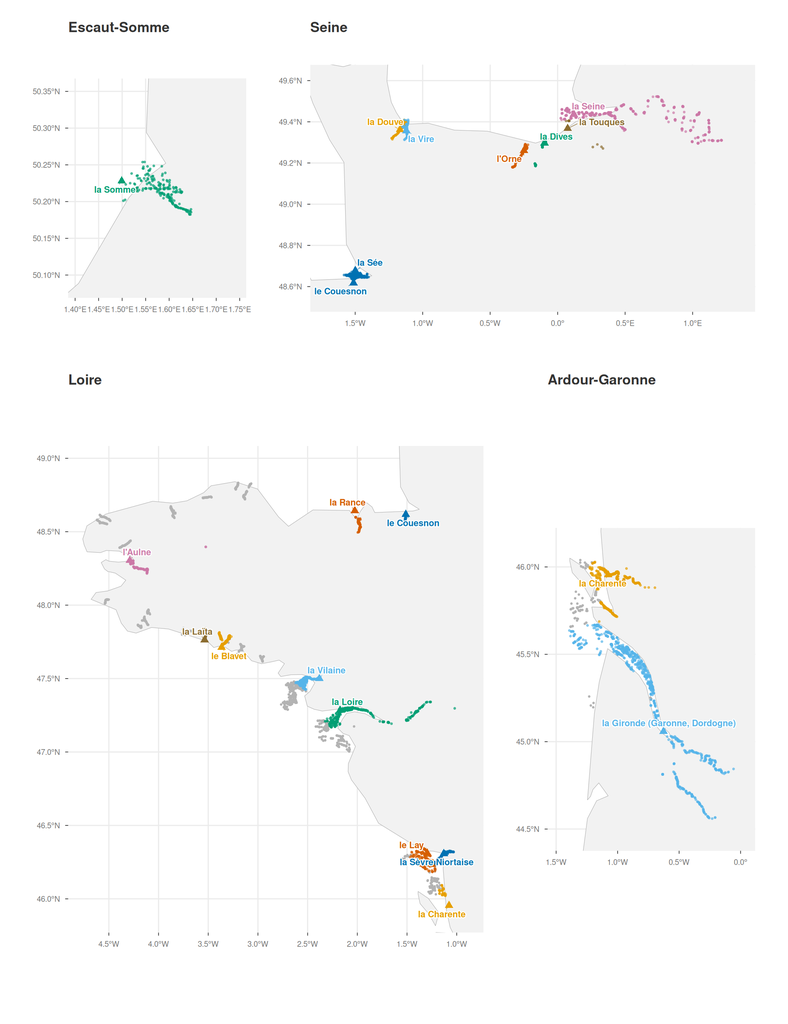

Operations coloured by their main river (triangle: mouth), per district; grey: dropped.

```r
map_district <- \(d) {
  op <- filter(operation_mouth, district == d)
  m <- filter(mouth_used, mouth_id %in% op$mouth_id)
  ggplot() +
    geom_sf(data = france, fill = "grey95", color = "grey70", linewidth = 0.2) +
    geom_point(aes(longitude, latitude), data = filter(op, is.na(mouth_id)), size = 0.4, color = "grey70") +
    geom_point(aes(longitude, latitude, color = factor(mouth_id)), data = filter(op, !is.na(mouth_id)), size = 0.5, alpha = 0.6) +
    geom_point(aes(longitude, latitude, color = factor(mouth_id)), data = m, shape = 17, size = 2.4) +
    ggrepel::geom_text_repel(
      aes(longitude, latitude, label = river, color = factor(mouth_id)), data = m,
      size = 2.8, fontface = "bold", bg.color = "white", bg.r = 0.15,
      min.segment.length = 0, segment.size = 0.2, max.overlaps = Inf, seed = 1
    ) +
    coord_sf(xlim = range(op$longitude) + c(-0.1, 0.1), ylim = range(op$latitude) + c(-0.1, 0.1)) +
    scale_color_manual(values = colour_mouth, guide = "none") +
    labs(x = NULL, y = NULL, title = d) +
    theme(axis.line = element_blank(), axis.text = element_text(size = 7))
}
row_north <- patchwork::wrap_plots(map_district("Escaut-Somme"), map_district("Seine"), widths = c(1, 2.5))
row_south <- patchwork::wrap_plots(map_district("Loire"), map_district("Ardour-Garonne"), widths = c(2, 1))
patchwork::wrap_plots(row_north, row_south, ncol = 1, heights = c(1, 2))
```

```r
operation_mouth |>
  filter(!is.na(mouth_id)) |>
  count(mouth_id, survey) |>
  tidyr::pivot_wider(names_from = survey, values_from = n, values_fill = 0) |>
  inner_join(mouth, by = "mouth_id") |>
  arrange(desc(area)) |>
  transmute(
    River = river, District = district, `POMET operations` = pomet,
    `Nursery survey operations` = nurse, `Catchment (km²)` = round(area)
  ) |>
  knitr::kable(format.args = list(big.mark = ","))
```

| River | District | POMET operations | Nursery survey operations | Catchment (km²) |
| --- | --- | --- | --- | --- |
| la Loire | Loire | 477 | 81 | 118,328 |
| la Gironde (Garonne, Dordogne) | Ardour-Garonne | 759 | 163 | 81,885 |
| la Seine | Seine | 1,145 | 0 | 76,446 |
| la Charente | Ardour-Garonne | 473 | 113 | 10,865 |
| la Vilaine | Loire | 121 | 215 | 10,490 |
| la Somme | Escaut-Somme | 207 | 0 | 6,564 |
| la Sèvre Niortaise | Loire | 155 | 21 | 3,951 |
| l’Orne | Seine | 248 | 0 | 2,973 |
| le Blavet | Loire | 499 | 0 | 2,521 |
| le Lay | Loire | 76 | 162 | 2,237 |
| la Vire | Seine | 131 | 0 | 2,022 |
| l’Aulne | Loire | 130 | 0 | 1,949 |
| la Dives | Seine | 84 | 0 | 1,783 |
| la Sée | Seine | 120 | 0 | 1,657 |
| le Couesnon | Loire | 176 | 0 | 1,597 |
| la Douve | Seine | 131 | 0 | 1,528 |
| la Touques | Seine | 18 | 0 | 1,296 |
| la Rance | Loire | 92 | 0 | 1,137 |
| la Laïta | Loire | 280 | 0 | 1,047 |

*To discuss:*

- Land use varies only between the 19 rivers, so its effects rest on few units.
- The bays dropped here could be added back with a land use exposure summing the main rivers nearby, weighted by distance at sea.

## Next steps

- Models of the communities against the catchment of their mouth: to start from scratch.

## References

Elliott, Michael, and Victor Quintino. 2007. “The Estuarine Quality Paradox, Environmental Homeostasis and the Difficulty of Detecting Anthropogenic Stress in Naturally Stressed Areas.” *Marine Pollution Bulletin* 54 (6): 640–45. https://doi.org/10.1016/j.marpolbul.2007.02.003.

Gounand, Isabelle, Chelsea J. Little, Eric Harvey, and Florian Altermatt. 2018. “Cross-Ecosystem Carbon Flows Connecting Ecosystems Worldwide.” *Nature Communications* 9 (1): 4825. https://doi.org/10.1038/s41467-018-07238-2.

Loreau, Michel, Nicolas Mouquet, and Robert D. Holt. 2003. “Meta-Ecosystems: A Theoretical Framework for a Spatial Ecosystem Ecology.” *Ecology Letters* 6 (8): 673–79. https://doi.org/10.1046/j.1461-0248.2003.00483.x.